# Assignment

10911963

11/12/2021

# Andrew Assignment

## This is it.

This is my assignment. First I am going to load my packages. # If you already install the package, then you need to use library()function before you need use those packages. If yoou need to install the package, use install.packages() functions. Also, you can click on Packages and click “install packages from local zip files”, then find the one you need and save it.

```r
library(tidyverse) # load the tidyverse
library(patchwork) # need to combine our plots at the end
library(Hmisc) # allow to use the stat_summary() function
library(gt) # make a gt table
library(ggridges) # calculates density estimates and draw the ridge line plot
library(cowplot) # arrange multiple plots
library(ggstatsplot) # create scatter plot
library(ggpubr) # provide simple way to create and customize 'ggplot2' which is based publication ready plots. Necessary for create scatter plot
```

# Let’s now read in the data

## The first step is how to read data in r? The most common way is to click the particular file, and it download to your computer. When you read your data, <- is a common to use, which means that you are assigning and saving the value into a variable, also <- means explained previously.

```r
assignment_1_data <- read.csv("assignment_1_data.csv", header = TRUE)
```

# Wrangle data first

## The first step to wrangle data is using str()function, it helps to examine and display the structure of data object.

```r
str(assignment_1_data)
```

```
## 'data.frame':    48 obs. of  5 variables:
##  $ ID        : int  1 2 3 4 5 6 7 8 9 10 ...
##  $ Condition1: int  1011 984 997 961 994 958 1001 1036 998 1023 ...
##  $ Condition2: int  1218 1223 1310 1260 1258 1226 1236 1238 1203 1202 ...
##  $ Condition3: int  1249 1248 1251 1221 1281 1219 1239 1228 1274 1260 ...
##  $ Condition4: int  992 1003 961 998 1008 946 989 991 958 1047 ...
```

## Then,rename conditions and reshape to longer format

### The next strp is useing pivot_longer()function to transfer from wild format to longer format.It should be using the tidyr package within the tidyverse.Another code common to use is %>%, which means pipe. In tidyverse, pipe usually used for data manipulations.The most easy way is to use pivot_longer()function to reshape the fromat from wild to long first. Then, use recode() function with factors could change the value, but also preserve the existing order of levels .Also, you can use recode_factor(), it helps to change the order of levels to match the order of replacements.Another function you may use below is mutate()function, which is used to create a new variable from a data set.

```r
assignment_long_data <- assignment_1_data %>%
  pivot_longer(cols = c(Condition1, Condition2, Condition3, Condition4),
               names_to = "Condition",
               values_to = "RT")
long_rename_data <- assignment_long_data %>%
  mutate(Condition = recode(Condition,
                            "Condition1" = "Number_Number",
                            "Condition2" = "Number_Letter",
                            "Condition3" = "Letter_Number",
                            "Condition4" = "Letter_Letter"))
```

### Also, Rename() function helps to replace, for example:

```r
rename(assignment_1_data,
       Number_Number = Condition1,
       Number_Letter = Condition2,
       Letter_Number = Condition3,
       Letter_Letter = Condition4)
```

```
##    ID Number_Number Number_Letter Letter_Number Letter_Letter
## 1   1          1011          1218          1249           992
## 2   2           984          1223          1248          1003
## 3   3           997          1310          1251           961
## 4   4           961          1260          1221           998
## 5   5           994          1258          1281          1008
## 6   6           958          1226          1219           946
## 7   7          1001          1236          1239           989
## 8   8          1036          1238          1228           991
## 9   9           998          1203          1274           958
## 10 10          1023          1202          1260          1047
## 11 11           993          1226          1277           979
## 12 12           989          1220          1246          1025
## 13 13           997          1235          1222           981
## 14 14           983          1241          1256          1014
```

[output cut: 34 more lines]

## Before the plots or summary, remember to check data first, and remove NA values. There are two fuctions you may use. The first one is filter()function, which is used to subset a data frame, and retaining all rows that may satisfy your conditions as well. !is.na()fuction returns a value of true and false for each value in a data set, which means check for not NA value.Value’NA’means not available,impossible value or missing value.

```r
filter(long_rename_data, !is.na(RT))
```

```
## # A tibble: 192 × 3
##       ID Condition        RT
##    <int> <chr>         <int>
##  1     1 Number_Number  1011
##  2     1 Number_Letter  1218
##  3     1 Letter_Number  1249
##  4     1 Letter_Letter   992
##  5     2 Number_Number   984
##  6     2 Number_Letter  1223
##  7     2 Letter_Number  1248
##  8     2 Letter_Letter  1003
##  9     3 Number_Number   997
## 10     3 Number_Letter  1310
## # … with 182 more rows
```

# summary data and create a gt table

## The next step is to summary data first. Use group_by()functioin use to group the dataframe. Summarise() function is used on grouped data created by group_by(), it is very useful with data has been grouped by one or more variables.Common to use summarise() with mean() which is calculated by taking the sum of the values and dividing with the number of values in a data series; median() which means the middle number of the dataset is ordered from smallest to largest; sd() which compute the standard deviation of given values; etc.

## After done the summaise, use gt package is easy to make a table, which could conveys the needed information better. The tab_header()function means you are able to add a title or/and subtitle to gt table. fmt_markdown() function helps to tansform to the approprite output type for markdown formate.

```r
long_rename_data %>%
  group_by(Condition) %>%
  summarise(Mean=mean(RT),
            SD=sd(RT),
            Median=median(RT),
            Min=min(RT),
            Max=max(RT)) %>%
  gt() %>%
  tab_header( title = "Summary Table for conditions") %>%
  fmt_markdown(columns = c(Condition))%>%
  fmt_markdown(columns = c(Mean))%>%
  fmt_markdown(columns = c(Median))%>%
  fmt_markdown(columns = c(SD))%>%
  fmt_markdown(columns = c(Min)) %>%
  fmt_markdown(columns = c(Max))
```

Summary Table for conditions

| Condition | Mean | SD | Median | Min | Max |
| --- | --- | --- | --- | --- | --- |
| Letter_Letter | 995.854166666667 | 29.6590480495527 | 997.5 | 899 | 1056 |
| Letter_Number | 1251.72916666667 | 27.9944824224219 | 1252.5 | 1184 | 1309 |
| Number_Letter | 1245.72916666667 | 29.8019987787006 | 1239.5 | 1202 | 1337 |
| Number_Number | 995.416666666667 | 26.5136121870573 | 995.5 | 928 | 1067 |

# Now, let’s start the Data visualization

# This is my first plots,which I use the point plot to have a general view.Most common one to use is str_to_title() function which helps to convert the first letter for everyword to be Uppercase, and others all be lower case. Also, geom_point()function use to creats a scatterplot in ggplot package.

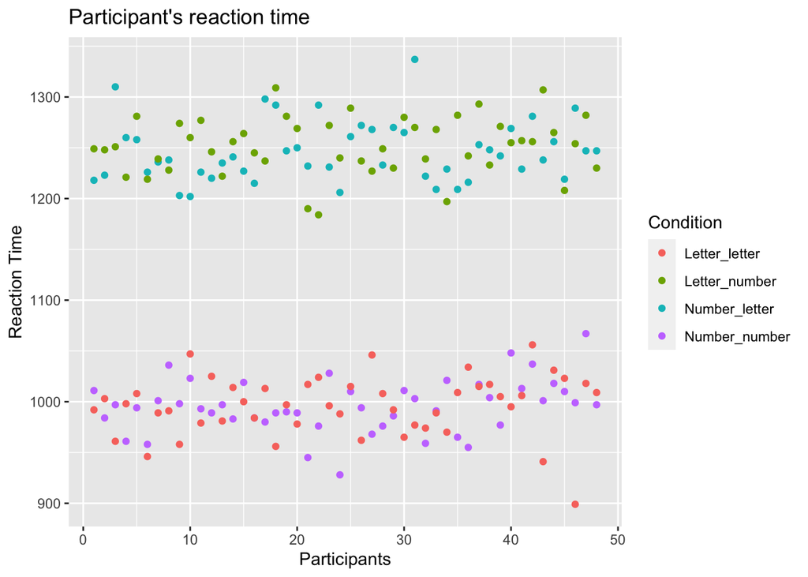

```r
# Point plot
long_rename_data %>%
  mutate(Condition = str_to_title(Condition)) %>%
  ggplot(aes(x = ID, y=RT, color= Condition))+
  labs(title = "Participant's reaction time",
       x = "Participants",
       y = "Reaction Time")+
  geom_point(na.rm = TRUE)
```

# Let’s seperete the point plot under the difference condition.

## We may have a view due to the last plot, but we may would like to have a clear view for each conditions. Therefore,we can use facet_wrap() funtion seperete by each conditions. facet_wrap() function able to wrap a 1d sequence of panels into 2d. ggplot()is a powerful and flexible package for r, you can use ggplot to control the mapping from data to aesthetics. geom_jitter()funtion will add small mount of random variiation to the location for each point, it is helpful to handling overplotting situation which caused by discreteness in some too small datasets. theme_minimal()function means a minimalistic theme without any backgroud.

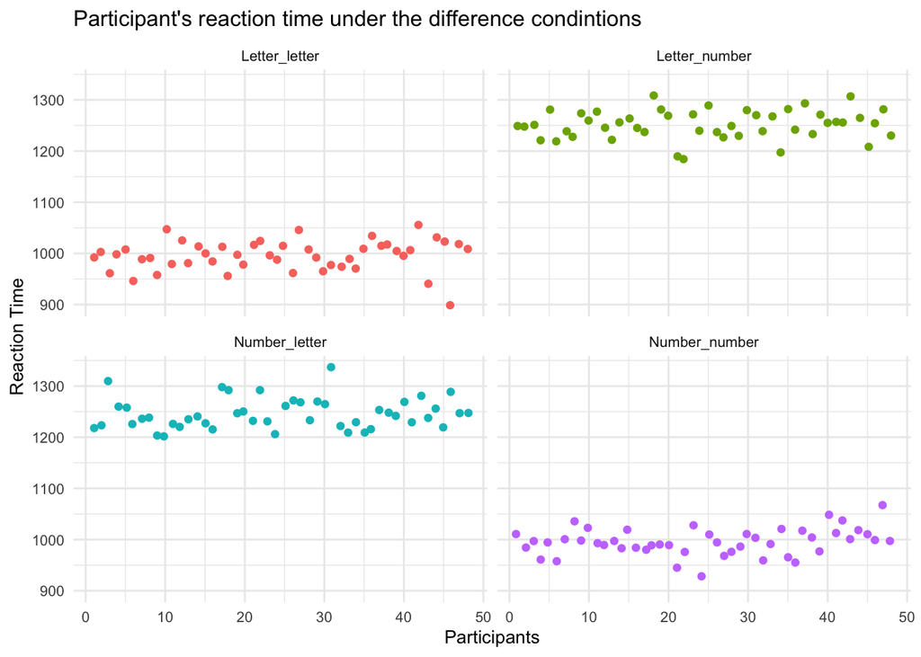

```r
long_rename_data %>%
  mutate(Condition = str_to_title(Condition)) %>%
  ggplot(aes(x = ID, y=RT, color= Condition))+
  geom_jitter(width = .2)+
  theme_minimal()+
  theme(text = element_text(size=10))+
  labs(title = "Participant's reaction time under the difference condintions",
       x = "Participants",
       y = "Reaction Time")+
  guides(color='none')+
  facet_wrap(~Condition)
```

## Now, let’s start with the density plots. I Put 4 density plots below with difference code and packages.

## Let’s start with the basic one which is the histogram. geom_histogram()function is common to use in ggplot package, and it dispaly the counts with bars.

[figure not shown]

```r
long_rename_data%>%
  ggplot(mapping = aes(x = RT))+
  geom_histogram(mapping = aes(fill = Condition))+
  labs(title = "Histogram of Reaction Time by density",
       x = "Reaction time",
       y = "Density")
```

## You may want to get the more direct information from each condition, therefore, we can use the facet_wrap()again to seperet conditions. geom_density() function is able to compute and draw kernel density estimate, Is much easier to read each condition now, right?

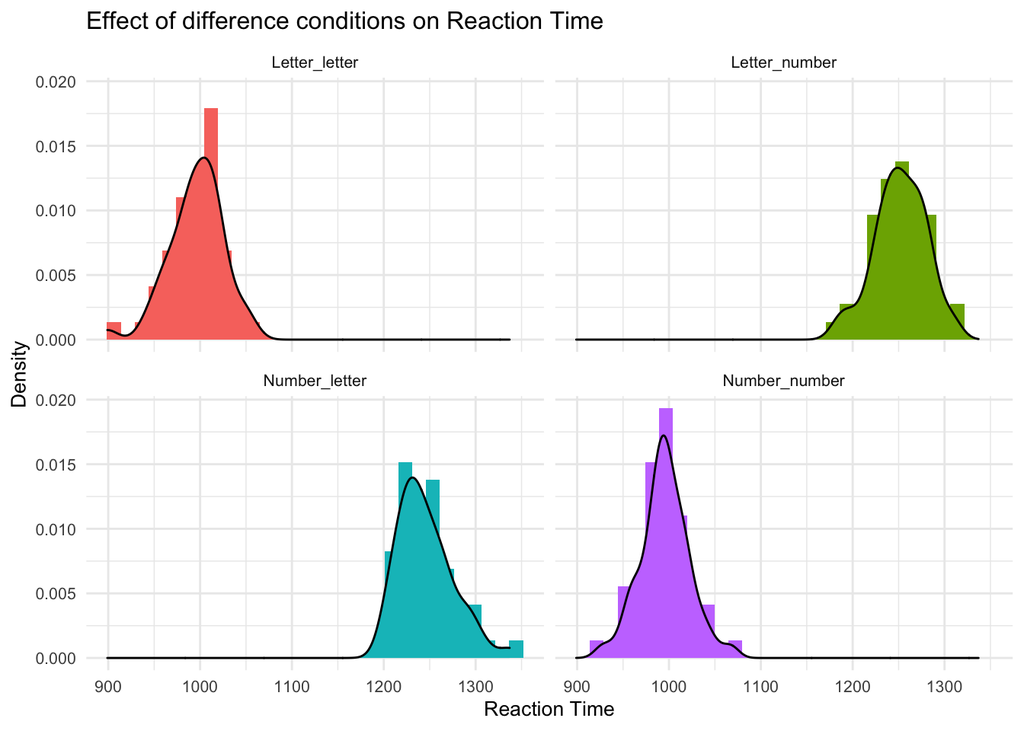

```r
long_rename_data %>%
  mutate(Condition = str_to_title(Condition)) %>%
  group_by(Condition) %>%
  ggplot(aes(x= RT, fill = Condition))+
  geom_histogram(aes(y=..density..))+
  geom_density(aes(y=..density..))+
  theme_minimal()+
  theme(text = element_text(size=10))+
  guides(fill='none')+
  labs(title = "Effect of difference conditions on Reaction Time",
       x = "Reaction Time",
       y = "Density")+
  facet_wrap(~ Condition)
```

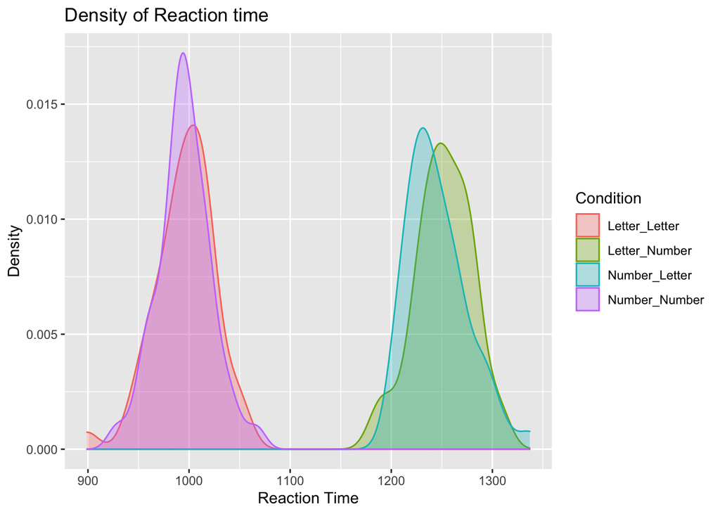

```r
long_rename_data %>%
  ggplot(mapping = aes(
    x=RT,
    color = Condition,
    fill = Condition))+
  geom_density(alpha=0.3)+
  labs(title = "Density of Reaction time",
       x= "Reaction Time",
       y= "Density")
```

## Now, we may able try the ggridges package amd use the geom_density_rides()function to creating a ridgeline plot. A numerical variabe and a categorical variable a density estimation of date, you could calculated and display for each group and get a ridgeline plot.

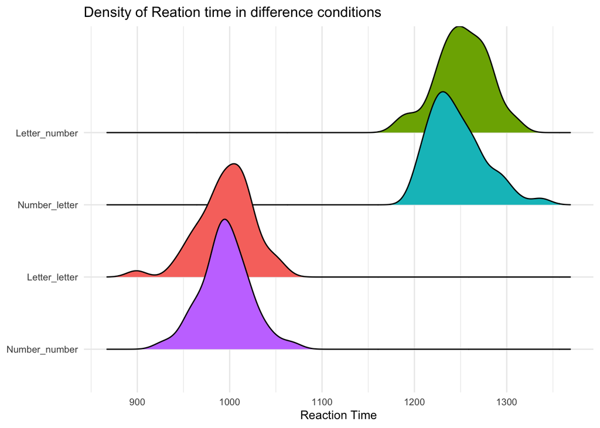

```r
long_rename_data %>%
  mutate(Condition=str_to_title(Condition)) %>%
  ggplot(aes(x = RT, y = fct_reorder(Condition,.fun = mean, RT)))+
  geom_density_ridges(aes(fill = Condition))+
  theme_minimal()+
  theme(text = element_text(size = 10)) +
  guides(fill = 'none') +
  labs(title = "Density of Reation time in difference conditions",
       x = "Reaction Time",
       y = NULL)
```

# Now, let’s move to the boxplot.

## This boxplot also used by ggplot, geom_violin() function help you to make a violin plot; and the geom_boxplot()function is the code help you to make a box plot. Normally, there will be other two code also common to use in box-plot. The first one is box_plot, which help you to aviod rewriting code each time when you add some new informtion. Another one is coord_flip() which help to flip the side of the graph.

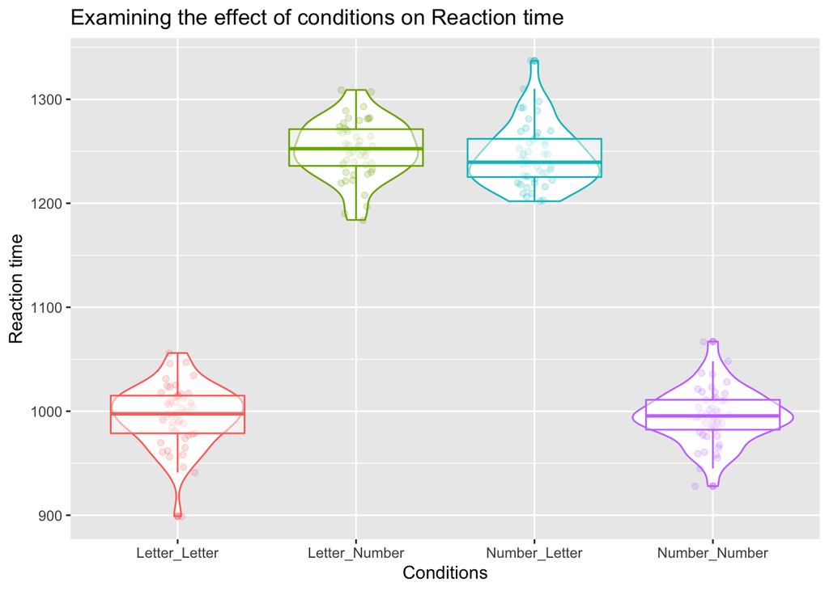

```r
long_rename_data %>%
  filter(!is.na(Condition ) & !is.na(RT)) %>%
  ggplot(aes(x = Condition, y = RT, color = Condition)) +
  geom_violin() +
  geom_jitter(alpha = .2, width = .1) +
  geom_boxplot(alpha = .5) +
  guides(colour = 'none') +
  labs(title = "Examining the effect of conditions on Reaction time",
       x = "Conditions",
       y = "Reaction time")
```

# My last plot to combine previous plots in one and create a scatter plot

## This plot require to install the cowplot package, ggpubr package and ggstatsplot package at the beginning. There are several new code that I use in this plot. xlab=“” means the x-axis lable, and ylab=““means y-axis lable.margin.plot()function means the graphing the result from the margin. Therefore, this scatter plot helps you get more information that you need just from one plot.

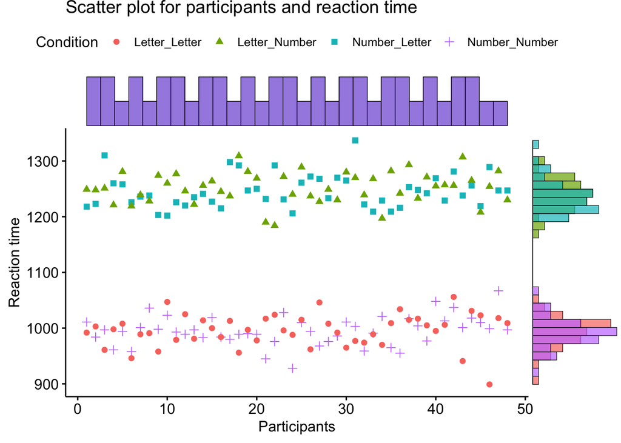

```r
ggscatterhist(long_rename_data,
                group = "Condition",
                x = "ID",
                y = "RT",
                xlab = "Participants",
                ylab = "Reaction time",
                color = "Condition",
                margin.plot = "histogram",
                marginal = TRUE,
                centrality.para = "mean",
                margin.params = list(fill = "Condition",
                                     color = "black",
                                     size = .2),
                title = "Scatter plot for participants and reaction time")
```

Thanks for your time, Enjoy and hope you have a nice day!